# Mapping the Solution to Gerrymandering

Statistics 199: Final Project

Seal Team Six - Bennett Stillerman, Ahana Sen, Victor Milev, Shari Tian

## Introduction

In the United States, political parties are given broad control over the drawing of electoral maps and the creation of the boundaries of Congressional Districts that then elect national-level representatives. Gerrymandering is the practice of drawing these boundaries in a way that favors a specific party. In the last decade, concerns over the gerrymandering of districts by both the Democratic and Republican Party have come to the forefront of American politics. After years of legislative infighting, multiple Supreme Court decisions, and several election cycles, the problem still has not been completely solved. Our research project is attempting to, broadly, identify the best map-drawing criterion for eliminating the harmful effects of gerrymandering, and creating the most “fair” elections. Our data comes a FiveThirtyEight created repository, where their politics team has devised a set of maps called “The Atlas of Redistricting” [^1]. The team worked to draw seven different district map types for every state that each accomplish different goals (e.g. highly compact districts, highly competitive districts). This publicly published data is a mix of demographic variables that come from 2010 Census data at the precinct and district level, political variables that are derived from past election results, and other probabilistic variables that are a function of both demographics and other political variables. Taken altogether, the data provides an extremely in-depth look at how the political landscape of America changes depending on how electoral maps are drawn.

The data is split into two separate files: the district file and the state file. The district file contains observations that represent every single Congressional district for every different map type. The file contains demographic data that breaks down all districts by each race and ethnicity, a variable that shows what the democratic chance of winning the district is (across a number of election cycles), their Partisan Voting Index (a measure of party affiliation based on past election results), and the likelihood it will elect a minority representative. Some variables, like democratic chance of winning, are mathematic and are the result of behind-the-scenes calculations that FiveThirtyEight does not publish. Nevertheless, all of the data is useful for getting a complete look at a districts characteristics.

The state file, by contrast, aggregates all the districts by state and separates them by map type, allowing us to study variables that vary at the state-level, like the average compactness of districts, their efficiency gap (a mathematical measure of unrepresentative a district’s elections are relative to the voting preferences of its constituents), which party the efficiency gap favors, and how many counties are split by a state’s districts. This file allows us to see how the changes in each district are reflected at the state-level when the map type is changed, and will be crucial to evaluating the effectiveness of each map type.

## Data Analysis Plan

As stated previously, our goal in this project is to study the ways in which different map drawing criterion affect different measures of electoral fairness. This would mean that our predictor variables would include:

1. The seven map types, which each maximize one of seven different measures: number of Republican districts, number of Democratic districts, proportion of partisanship, district competitiveness, number of districts with a single minority group making up a majority of voting population, lowest average distance between constituent and district’s geographic center compactness, and lowest number of county splits.
2. In addition to focusing on the map types, we could examine the specific variables considered when drawing the maps, but in the context of every possible map. These would include: district perimeter measures and the number of county splits.

Generally, our aim is to increase the fairness of elections, but the definition of this concept is a highly debated one in the academic context (both legally and mathematically). As such, we hope to establish a variety of measures of possible fairness that can serve as response variables, including, but not limited to:

1. Efficiency gap: essentially a measure of the number of wasted votes in a district
2. Partisan Voting Index (PVI): a measure of how extreme a district’s partisan make-up is

A more theoretical analysis of the efficacy and quality of these response variables as representatives of fairness is to follow.

### Exploratory Data Analysis

A quick review of the robustness of this data might be worthwhile. From FiveThirtyEight’s data descriptions it seems like there are two possible outright issues with the data – firstly, there are some states that have only one congressional district representing the whole state.

```r
library(tidyverse)
library(broom)
library(infer)
library(patchwork)
```

```r
states <- read.csv("Data/states.csv")
districts <- read.csv("Data/districts.csv")
```

```r
districts %>%
  filter(district == 0, maptype == "current") %>%
  select(statefp, state, district )
```

| statefp | state | district |
| --- | --- | --- |
| 2 | AK | 0 |
| 10 | DE | 0 |
| 30 | MT | 0 |
| 38 | ND | 0 |
| 46 | SD | 0 |
| 50 | VT | 0 |
| 56 | WY | 0 |

This seems to be case for only 7 states, which represent only 7/435 districts nation-wide. We should be able to conduct our analysis without considering these states since the drawing of district maps is not something that does on within them.

```r
districtsNOSINGLE <- districts %>%
  filter(district != 0)
```

The second concern is that some types of maps were impossible to draw for specific states. In those cases, FiveThirtyEight analysts created maps that came as close to accomplishing those goals as possible, but it still might be useful to see how often and where this was the case:

```r
districts %>%
  filter(impossible == "true") %>%
  count(state)
```

| state | n |
| --- | --- |
| HI | 6 |
| IA | 4 |
| ID | 8 |
| KS | 4 |
| KY | 6 |
| MA | 9 |
| ME | 2 |
| MN | 8 |
| NE | 3 |
| NH | 2 |

[output cut: 5 more lines]

```r
districts %>%
  filter(impossible == "true") %>%
  count(maptype)
```

| maptype | n |
| --- | --- |
| Competitive | 7 |
| Dem | 5 |
| GOP | 2 |
| MajMin | 50 |
| Proportional | 23 |

There are 15 states that had impossible maps and the majority-minority maps seemed to be the hardest to draw.

Despite these anamolies, the data still seems to provide a pretty robust look at the effects of congressional map drawing on different electoral outcomes.

We can examine the data for general trends by using a preliminary box plot observing the relationship between different map types and one of the explanatory variables. In this case, we can look at map types and the effeciency gap (a measure where a more negative value indicates ineffecient bias towards Democrats, and a more positive value is towards Republicans). The value 0 of an efficiency gap would signify perfectly efficient elections.

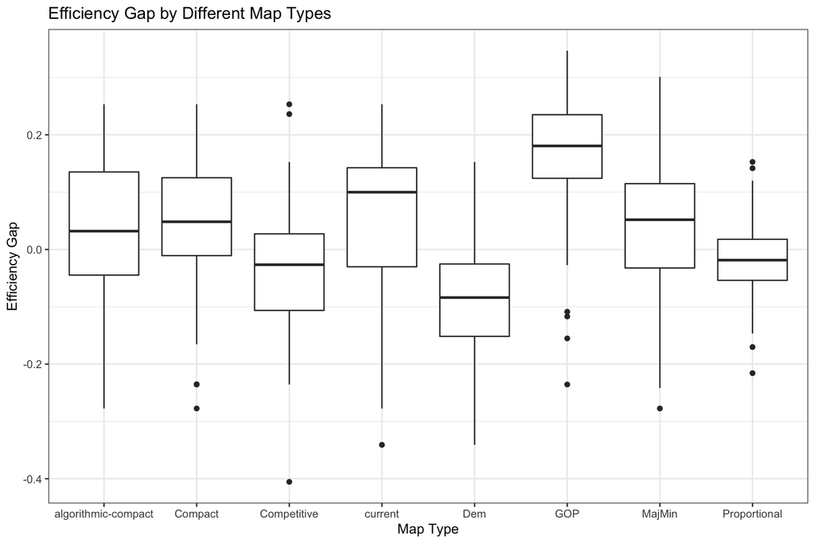

```r
ggplot(data = states, mapping = aes(y = efficiency_gap, x = maptype))+
  geom_boxplot()+
  theme_bw()+
  labs(title = "Efficiency Gap by Different Map Types", y = "Efficiency Gap", x = "Map Type")
```

This plot shows us some interesting starting trends. Firstly, it seems that current map drawings tend towards a Republican effeciency bias. It also interesting to note that maps particularly devised to help Democrats are not as ineffecient as maps that help Republicans. Generally, the trends on this map can help us in choosing which map types (and their underlying optimized factors) to look more closely at. For example, compactly drawn districts seem to be more effecient.

We can also look at the relationship between map type and the amount of majority-minority districts created.

```r
districts <- districts %>%
  mutate(MajMinBool = if_else(race_category == "Non-Hispanic White Majority", "No", "Yes"))



districts %>%
  select(maptype, MajMinBool) %>%
  group_by(maptype, MajMinBool) %>%
  count()
```

| maptype | MajMinBool | n |
| --- | --- | --- |
| algorithmic-compact | No | 346 |
| algorithmic-compact | Yes | 89 |
| Compact | No | 343 |
| Compact | Yes | 92 |
| Competitive | No | 344 |
| Competitive | Yes | 91 |
| current | No | 340 |
| current | Yes | 95 |
| Dem | No | 337 |
| Dem | Yes | 98 |

[output cut: 6 more lines]

It does not seem that there is a large variance in the number of majority-minority districts (except of course for the map type that has been optimized to create the most). This might indicate that this is not a robust variable to utilize and that we might want to direct our attention to the specific race groups or to ignore this measure all together.

### Statistical methods

There are several techniques we can use to assess how different map drawings can limit the effects of gerrymandering. The main statistical methods that we propose would be the most effective for answering our question of which map maximizes election fairness would be those involved in linear regression. These include single and multiple regression modeling, backwards elimination, and tests for linearity.

Through single regression modeling, we can analyze how certain quantitative response variables like efficiency gap and PVI change depending on the variables that determine the map type. Similarly, through modeling with multiple predictors, we can analyze how these response variables change depending on multiple map-determining variables at a time in the presence and absence of interactions.

For selection of the best linear model, we can perform a backwards elimination using AIC. The results from this method would allow us to see which map-determining variables provide the best linear relationship with efficiency gap or PVI.

For all of the models generated from the techniques listed above, we can test the linearity assumption through analysis of the residual plots. The results from this analysis would provide further evidence of how well each map type can minimize the effects of gerrymandering. A model that satisfies the linearity assumption can reinforce existing conclusions about the relationship between different map-determining variables and election fairness.

We hypothesize that the map that draws districts to match the partisan breakdown of seats to the electorate would be the most effective at limiting the harms of gerrymandering. In order for this hypothesis to be supported, the data should allow for the most linear models to occur between variables that determine this map and efficiency gap or PVI.

## Data

```r
glimpse(districts)
```

```
Observations: 3,480
Variables: 20
$ statefp            <int> 2, 2, 2, 2, 2, 2, 2, 2, 1, 1, 1, 1, 1, 1, 1, …
$ state              <fct> AK, AK, AK, AK, AK, AK, AK, AK, AL, AL, AL, A…
$ maptype            <fct> Compact, Competitive, Dem, GOP, MajMin, Propo…
$ district           <int> 0, 0, 0, 0, 0, 0, 0, 0, 1, 2, 3, 4, 5, 6, 7, …
$ population         <int> 710231, 710231, 710231, 710231, 710231, 71023…
$ population_18_over <int> 522853, 522853, 522853, 522853, 522853, 52285…
$ PVI                <dbl> -9.39, -9.39, -9.39, -9.39, -9.39, -9.39, -9.…
$ dem_chance         <dbl> 5.40942673, 5.40942673, 5.40942673, 5.4094267…
$ Non.Hispanic.White <dbl> 68.27674, 68.27674, 68.27674, 68.27674, 68.27…
$ African.American   <dbl> 3.084806, 3.084806, 3.084806, 3.084806, 3.084…
$ Hispanic.Latino    <dbl> 4.673780, 4.673780, 4.673780, 4.673780, 4.673…
$ Asian              <dbl> 5.3328565, 5.3328565, 5.3328565, 5.3328565, 5…
$ Native.American    <dbl> 13.2700778, 13.2700778, 13.2700778, 13.270077…
$ Pacific.Islander   <dbl> 0.85989752, 0.85989752, 0.85989752, 0.8598975…
$ Other              <fct> 4.501838948997137%, 4.501838948997137%, 4.501…
$ race_category      <fct> Non-Hispanic White Majority, Non-Hispanic Whi…
$ minority_chance    <dbl> 9.8894051, 9.8894051, 9.8894051, 9.8894051, 9…
$ current_map        <fct> , , , , , , , , , , , , , , , , , , , , , , ,…
$ impossible         <fct> , , , , , , , , , , , , , , , , , , , , , , ,…
$ MajMinBool         <chr> "No", "No", "No", "No", "No", "No", "No", "No…
```

```r
glimpse(states)
```

```
Observations: 400
Variables: 11
$ statefp                    <int> 2, 2, 2, 2, 2, 2, 2, 2, 1, 1, 1, 1, 1…
$ state                      <fct> AK, AK, AK, AK, AK, AK, AK, AK, AL, A…
$ maptype                    <fct> Compact, Competitive, Dem, GOP, MajMi…
$ districts                  <int> 1, 1, 1, 1, 1, 1, 1, 1, 7, 7, 7, 7, 7…
$ county_splits              <int> 0, 0, 0, 0, 0, 0, 0, 0, 5, 12, 8, 8, …
$ efficiency_gap             <dbl> NA, NA, NA, NA, NA, NA, NA, NA, -0.05…
$ efficiency_gap_extra_seats <fct> , , , , , , , , D+0, D+0, D+0, R+1, D…
$ district_perimeters        <dbl> NA, NA, NA, NA, NA, NA, NA, NA, 55.39…
$ state_perimeter            <dbl> NA, NA, NA, NA, NA, NA, NA, NA, 18.98…
$ interior_perimeter_measure <dbl> NA, NA, NA, NA, NA, NA, NA, NA, 18.20…
$ compactness_rank           <int> NA, NA, NA, NA, NA, NA, NA, NA, 1, 6,…
```

## Initial Data Wrangling

We will be using the observations from the states dataset as our points of analysis, but there are some measures in the states dataset that need to be changed to reflect the nature of our analysis and some measures from district that need to be integrated in to states.

We will get rid of observations from Alaska, Delaware, Montana, North Dakota, South Dakota, Vermont and Wyoming since they don’t have different congressional districts.

```r
statesNOSINGLE <- na.omit(states)
```

We will add the following variables (modified from states or added from districts):

npPVI: A non-partisan aggregated version of the PVI. The absolute value of the PVI of each district within a map will be added together to calculate the non-partisan PVI of every map

maj-min: The proportion of majority-minority districts in a state in a map

min_chance: The proportion of districts in a state where a minority has above a 50% chance of winning

npefficiency_gap: A non-partisan version of the efficiency gap. The absolute value of efficiency gap variable in states

```r
statesNOSINGLE <- statesNOSINGLE %>%
  mutate(npefficiency_gap= abs(efficiency_gap))
```

```r
districtsNOSINGLE <- districtsNOSINGLE %>%
  mutate(npPVI = abs(PVI))
```

```r
mapPVIcalc <- districtsNOSINGLE %>%
  group_by(state, maptype) %>%
  summarize(npPVI = sum(npPVI))

FullStates <- inner_join(statesNOSINGLE, mapPVIcalc)
```

```r
districtsNOSINGLE <- districtsNOSINGLE %>%
  mutate(majmin = if_else(race_category == "Non-Hispanic White Majority", 0, 1))
```

```r
majmincalc <- districtsNOSINGLE %>%
  group_by(state, maptype) %>%
  summarize(maj_min = sum(majmin)/n())

FullStates <- inner_join(FullStates, majmincalc)
```

```r
districtsNOSINGLE <- districtsNOSINGLE %>%
  mutate(minchanceagg = if_else(minority_chance > 50, 1, 0))
```

```r
minchancecalc<- districtsNOSINGLE %>%
  group_by(state, maptype) %>%
  summarize(min_chance = sum(minchanceagg)/n())

FullStates <- inner_join(FullStates, minchancecalc)
```

Next, we will add some geographical and partisan signifiers to each of the states. The regions are as designated by the Census Bureau (Northeast, Midwest, South, West)[^2]. Partisan labels are as designated by a Gallup poll conducted in 2018[^3]

```r
north = c("CT", "ME","MA", "NH", "RI", "VT", "NJ", "NY", "PA" )
south = c("DE", "FL", "GA", "MD", "NC", "SC", "VA", "WV", "AL", "KY", "MS", "TN",
          "AR", "LA", "OK", "TX")
west = c("AZ", "CA", "CO", "ID", "NM", "MT", "UT", "NV", "WY", "AK", "HI", "OR", "WA")
midwest = c("IN", "IL", "MI", "OH", "WI", "IA", "KS", "MN", "MO", "NE", "ND", "SD")

dem = c("CA", "NV", "OR", "WA", "NM", "CO", "MN", "IL", "MI", "ME", "NH", "VT", "MA",
        "RI", "NY", "CT", "NJ", "DE", "MD", "PA", "VA", "HI")
GOP = c("ID", "UT", "WY", "MT", "ND", "SD", "KS", "OK", "MO", "AR", "LA", "MS", "AL",
        "TN", "SC", "WV", "IN", "AK")

swing = c("AZ", "NE", "TX", "IA","WI", "OH", "KY", "NC", "GA", "FL")
```

```r
FullStates <- FullStates %>%
  mutate(region = ifelse(state %in% north, "North",
                         ifelse(state %in% south, "South",
                                ifelse(state %in% west, "West", "Midwest" ))))

FullStates <- FullStates %>%
  mutate(PartisanLeaning = ifelse(state %in% dem, "Dem",
                         ifelse(state %in% GOP, "GOP", "Swing")))
```

## Methods and Results

There are two measures that we want to be able to predict through the use of linear models:

1. Efficiency Gap (`npefficiency_gap`)
2. PVI (`npPVI`)

The predictors we want to test are:

1. Interior perimeter measure (`interior_perimeter_measure`)
2. Number of county splits (`county_splits`)
3. Compactness rankings (`compactness_rank`)
4. Number of majority-minority districts (`maj_min`)
5. Minority chance of winning (`min_chance`)
6. Map type (`maptype`)

We will first perform an AIC backwards elimination to determine the best possible predictors for each response variable, efficiency gap and PVI.

**For efficiency gap:**

```r
lm_full <- lm(npefficiency_gap ~ interior_perimeter_measure + county_splits + compactness_rank + maj_min + min_chance + factor(maptype), data = FullStates)

lm_efficiency <- step(lm_full, direction = "backward")
```

```
Start:  AIC=-1788.18
npefficiency_gap ~ interior_perimeter_measure + county_splits +
    compactness_rank + maj_min + min_chance + factor(maptype)

                             Df Sum of Sq    RSS     AIC
- maj_min                     1   0.00037 1.7631 -1790.1
- min_chance                  1   0.00073 1.7635 -1790.0
- county_splits               1   0.00187 1.7646 -1789.8
<none>                                    1.7628 -1788.2
- compactness_rank            1   0.04299 1.8057 -1781.9
- interior_perimeter_measure  1   0.05528 1.8180 -1779.5
- factor(maptype)             7   0.33592 2.0987 -1742.2

Step:  AIC=-1790.1
npefficiency_gap ~ interior_perimeter_measure + county_splits +
    compactness_rank + min_chance + factor(maptype)

                             Df Sum of Sq    RSS     AIC
- county_splits               1   0.00178 1.7649 -1791.8
- min_chance                  1   0.00832 1.7714 -1790.5
<none>                                    1.7631 -1790.1
- compactness_rank            1   0.04309 1.8062 -1783.8
- interior_perimeter_measure  1   0.05576 1.8189 -1781.4
- factor(maptype)             7   0.33623 2.0993 -1744.1

Step:  AIC=-1791.76
npefficiency_gap ~ interior_perimeter_measure + compactness_rank +
    min_chance + factor(maptype)

                             Df Sum of Sq    RSS     AIC
- min_chance                  1   0.00813 1.7730 -1792.2
<none>                                    1.7649 -1791.8
- compactness_rank            1   0.04261 1.8075 -1785.5
- interior_perimeter_measure  1   0.11709 1.8820 -1771.7
- factor(maptype)             7   0.33495 2.0998 -1746.0

Step:  AIC=-1792.17
npefficiency_gap ~ interior_perimeter_measure + compactness_rank +
    factor(maptype)

                             Df Sum of Sq    RSS     AIC
<none>                                    1.7730 -1792.2
- compactness_rank            1   0.04665 1.8197 -1785.2
- interior_perimeter_measure  1   0.14145 1.9145 -1767.8
- factor(maptype)             7   0.33699 2.1100 -1746.3
```

```r
tidy(lm_efficiency)
```

| term | estimate | std.error | statistic | p.value |
| --- | --- | --- | --- | --- |
| (Intercept) | 0.111414174 | 0.013791924 | 8.0782186 | 1.210723e-14 |
| interior_perimeter_measure | -0.001088768 | 0.000210920 | -5.1619953 | 4.203575e-07 |
| compactness_rank | 0.006383679 | 0.002153335 | 2.9645551 | 3.249145e-03 |
| factor(maptype)Compact | -0.001919159 | 0.016329812 | -0.1175249 | 9.065148e-01 |
| factor(maptype)Competitive | -0.014077342 | 0.015722103 | -0.8953854 | 3.712259e-01 |
| factor(maptype)current | 0.016696800 | 0.016252350 | 1.0273468 | 3.050006e-01 |
| factor(maptype)Dem | -0.016019607 | 0.016276205 | -0.9842348 | 3.257125e-01 |
| factor(maptype)GOP | 0.067500227 | 0.016120862 | 4.1871351 | 3.617901e-05 |
| factor(maptype)MajMin | -0.010749771 | 0.016057831 | -0.6694411 | 5.036766e-01 |
| factor(maptype)Proportional | -0.051387087 | 0.015727312 | -3.2673789 | 1.198263e-03 |

The $r^2$ value:

```r
glance(lm_efficiency) %>%
  pull(adj.r.squared)
```

```
[1] 0.2199911
```

**For PVI:**

```r
lm_full2 <- lm(npPVI ~ interior_perimeter_measure + county_splits + compactness_rank + maj_min + min_chance + factor(maptype), data = FullStates)

lm_pvi <- step(lm_full2, direction = "backward")
```

```
Start:  AIC=2898.18
npPVI ~ interior_perimeter_measure + county_splits + compactness_rank +
    maj_min + min_chance + factor(maptype)

                             Df Sum of Sq     RSS    AIC
- min_chance                  1      1654 1455898 2896.6
<none>                                    1454244 2898.2
- maj_min                     1     33259 1487503 2904.0
- compactness_rank            1     68597 1522842 2912.0
- factor(maptype)             7    135323 1589568 2914.8
- county_splits               1    271850 1726095 2955.1
- interior_perimeter_measure  1    902208 2356453 3062.2

Step:  AIC=2896.57
npPVI ~ interior_perimeter_measure + county_splits + compactness_rank +
    maj_min + factor(maptype)

                             Df Sum of Sq     RSS    AIC
<none>                                    1455898 2896.6
- compactness_rank            1     67934 1523832 2910.3
- factor(maptype)             7    134651 1590549 2913.0
- maj_min                     1     92737 1548635 2915.8
- county_splits               1    273605 1729504 2953.8
- interior_perimeter_measure  1    900893 2356792 3060.3
```

```r
tidy(lm_pvi)
```

| term | estimate | std.error | statistic | p.value |
| --- | --- | --- | --- | --- |
| (Intercept) | -59.306064 | 14.7745898 | -4.014058 | 7.382124e-05 |
| interior_perimeter_measure | 4.804776 | 0.3352223 | 14.333102 | 1.325035e-36 |
| county_splits | 2.675381 | 0.3387037 | 7.898883 | 4.164590e-14 |
| compactness_rank | -7.737562 | 1.9658801 | -3.935928 | 1.009814e-04 |
| maj_min | 73.881549 | 16.0659654 | 4.598637 | 6.055567e-06 |
| factor(maptype)Compact | 83.994146 | 17.5987717 | 4.772728 | 2.728617e-06 |
| factor(maptype)Competitive | 46.006496 | 16.4800065 | 2.791655 | 5.547518e-03 |
| factor(maptype)current | 69.539216 | 17.4626373 | 3.982171 | 8.394071e-05 |
| factor(maptype)Dem | 54.285545 | 16.3461918 | 3.320990 | 9.968208e-04 |
| factor(maptype)GOP | 73.999539 | 16.7148419 | 4.427176 | 1.297206e-05 |

[output cut: 2 more lines]

The $r^2$ value:

```r
glance(lm_pvi) %>%
  pull(adj.r.squared)
```

```
[1] 0.8140676
```

Comparing the adjusted R-squared values, the model showing how different predictors can affect PVI seems to better resemble a linear relationship than that for efficiency gap.

Before we conduct any inference tests, let’s first verify the linear model assumptions for both the efficiency gap and PVI models.

```r
plot_diagnostics <- function(x) {

  p_variance <- augment(x) %>%
    ggplot(aes(x = .fitted, y = .resid)) +
    geom_point(color='darkblue') +
    labs(x = expression(hat(y)), y = "Residual value") +
    theme_minimal(base_size = 16)

  p_normality <- augment(x) %>%
    ggplot(aes(x = .resid)) +
    geom_histogram(alpha = .5, color = "darkred") +
    labs(x = "Residual value", y = "Count") +
    theme_minimal(base_size = 16)

  p_independence <- augment(x) %>%
    ggplot(aes(x = 1:nrow(FullStates), y = .resid)) +
    geom_point(color='darkblue') +
    labs(x = "Index", y = "Residual value") +
    theme_minimal(base_size = 16)

  p_variance / (p_normality + p_independence)
}
```

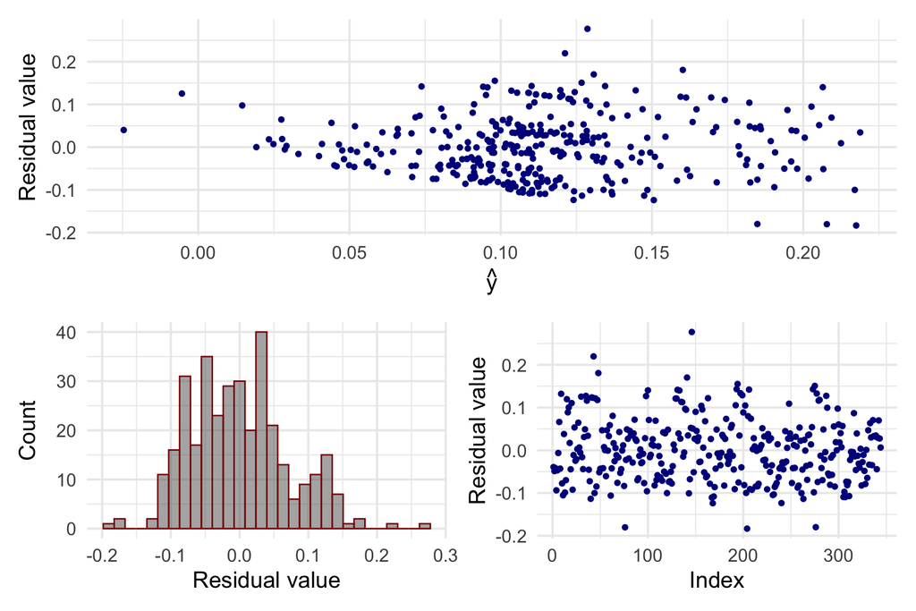

```r
plot_diagnostics(lm_efficiency)
```

From these plots, we can verify that the observations are independent, the residuals are nearly normally distributed, there is constant variance, and the residuals seem to be relatively centered around 0.

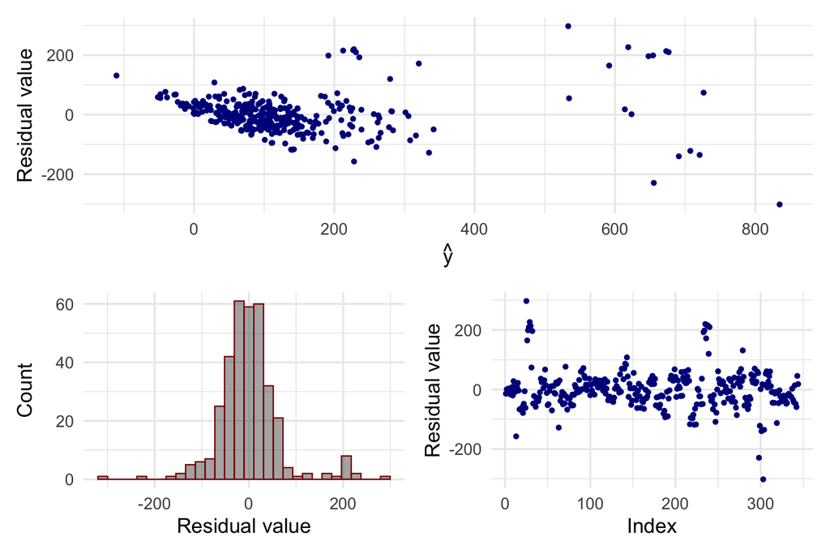

```r
plot_diagnostics(lm_pvi)
```

We will perform a CLT-based hypothesis test on the regression coefficients of only the PVI model, for its adjusted R squared value indicates that it better resembles a linear relationship than the efficiency gap model.

The null and alternative hypotheses are as follows:

$H_0: \beta_k = 0$

$H_1: \beta_k \neq 0$

where $\beta_k$ is the regression coefficient of each predictor variable.

In the context of the problem, the null hypothesis states that there is no relationship between any predictor variable and the non-partisan PVI, whereas the alternative hypothesis states that there is a relationship.

```r
tidy(lm_pvi) %>%
  select(term, p.value)
```

| term | p.value |
| --- | --- |
| (Intercept) | 7.382124e-05 |
| interior_perimeter_measure | 1.325035e-36 |
| county_splits | 4.164590e-14 |
| compactness_rank | 1.009814e-04 |
| maj_min | 6.055567e-06 |
| factor(maptype)Compact | 2.728617e-06 |
| factor(maptype)Competitive | 5.547518e-03 |
| factor(maptype)current | 8.394071e-05 |
| factor(maptype)Dem | 9.968208e-04 |
| factor(maptype)GOP | 1.297206e-05 |

[output cut: 2 more lines]

At the $\alpha$ = 0.05 significance level, we reject the null hypothesis for all of the predictor variables, which states that there is no relationship between the predictor variable and the non-partisan PVI.

Based on the residual related anamolies of the PVI model, it might be prudent to recreate models for states based on their geographic locations. States within the same geographic region share a lot of tangible (e.g. population, climate) and intangible (e.g. culture, political attitudes) factors that could make our linear models more focused. The efficiency gap measure is disregarded in the following analysis because of low $r^2$ value found in the broader linear model fitted above.

We recreate the process above, but using filtering for different geographic regions:

**North**

```r
FullStatesNorth <- FullStates %>%
  filter(region == "North")
```

Finding best-fit linear model PVI for states in the North:

```r
lm_full_north_pvi <- lm(npPVI ~ interior_perimeter_measure + county_splits + compactness_rank + maj_min + min_chance + factor(maptype), data = FullStatesNorth)

lm_pvi_north <- step(lm_full_north_pvi, direction = "backward", results = "hide")
```

```
Start:  AIC=490.19
npPVI ~ interior_perimeter_measure + county_splits + compactness_rank +
    maj_min + min_chance + factor(maptype)

                             Df Sum of Sq    RSS    AIC
- factor(maptype)             7      4458  94848 479.27
- maj_min                     1       268  90657 488.38
- county_splits               1       931  91321 488.85
<none>                                     90390 490.19
- compactness_rank            1      8765  99155 494.12
- interior_perimeter_measure  1     40124 130513 511.70
- min_chance                  1     50378 140768 516.54

Step:  AIC=479.27
npPVI ~ interior_perimeter_measure + county_splits + compactness_rank +
    maj_min + min_chance

                             Df Sum of Sq    RSS    AIC
- maj_min                     1       366  95214 477.52
- county_splits               1      1340  96187 478.17
<none>                                     94848 479.27
- compactness_rank            1     12884 107731 485.42
- interior_perimeter_measure  1     53182 148030 505.76
- min_chance                  1     58346 153193 507.96

Step:  AIC=477.52
npPVI ~ interior_perimeter_measure + county_splits + compactness_rank +
    min_chance

                             Df Sum of Sq    RSS    AIC
- county_splits               1      1065  96278 476.23
<none>                                     95214 477.52
- compactness_rank            1     12519 107733 483.43
- interior_perimeter_measure  1     63536 158750 508.24
- min_chance                  1    250953 346167 558.13

Step:  AIC=476.23
npPVI ~ interior_perimeter_measure + compactness_rank + min_chance

                             Df Sum of Sq    RSS    AIC
<none>                                     96278 476.23
- compactness_rank            1     12722 109001 482.17
- interior_perimeter_measure  1    139122 235400 531.45
- min_chance                  1    339480 435759 570.86
```

```r
tidy(lm_pvi_north)
```

| term | estimate | std.error | statistic | p.value |
| --- | --- | --- | --- | --- |
| (Intercept) | 24.008201 | 11.3067499 | 2.123351 | 3.785776e-02 |
| interior_perimeter_measure | 4.872985 | 0.5233422 | 9.311279 | 2.966049e-13 |
| compactness_rank | -6.459452 | 2.2940345 | -2.815761 | 6.575101e-03 |
| min_chance | 986.815982 | 67.8449522 | 14.545164 | 2.464804e-21 |

The $r^2$ value:

```r
glance(lm_pvi_north) %>%
  pull(adj.r.squared)
```

```
[1] 0.9171202
```

```r
plot_diagnostics_region <- function(x,y) {

  p_variance <- augment(x) %>%
    ggplot(aes(x = .fitted, y = .resid)) +
    geom_point(color='darkblue') +
    labs(x = expression(hat(y)), y = "Residual value") +
    theme_minimal(base_size = 16)

  p_normality <- augment(x) %>%
    ggplot(aes(x = .resid)) +
    geom_histogram(alpha = .5, color = "darkred") +
    labs(x = "Residual value", y = "Count") +
    theme_minimal(base_size = 16)

  p_independence <- augment(x) %>%
    ggplot(aes(x = 1:nrow(y), y = .resid)) +
    geom_point(color='darkblue') +
    labs(x = "Index", y = "Residual value") +
    theme_minimal(base_size = 16)

  p_variance / (p_normality + p_independence)
}
```

Lookings at the linear model assumptions for this linear model:

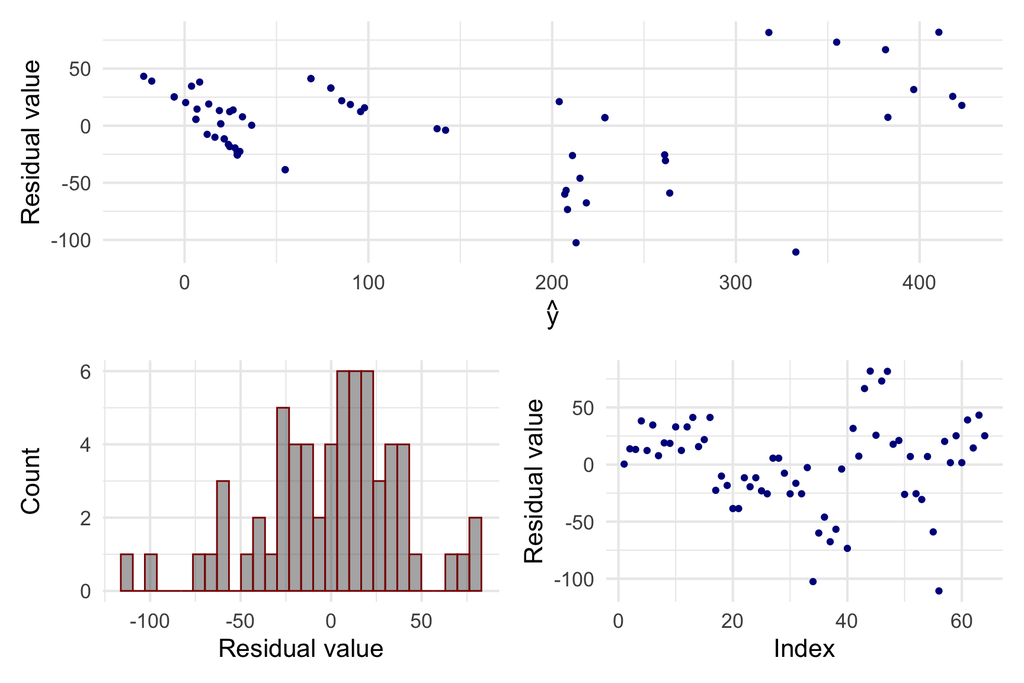

```r
plot_diagnostics_region(lm_pvi_north, FullStatesNorth)
```

**South**

```r
FullStatesSouth <- FullStates %>%
  filter(region == "South")
```

Finding best-fit linear model PVI for states in the South:

```r
lm_full_south_pvi <- lm(npPVI ~ interior_perimeter_measure + county_splits + compactness_rank + maj_min + min_chance + factor(maptype), data = FullStatesSouth)

lm_pvi_south <- step(lm_full_south_pvi, direction = "backward", results = "hide")
```

```
Start:  AIC=908.9
npPVI ~ interior_perimeter_measure + county_splits + compactness_rank +
    maj_min + min_chance + factor(maptype)

                             Df Sum of Sq    RSS     AIC
- county_splits               1      1468 189624  907.84
<none>                                    188156  908.90
- factor(maptype)             7     25789 213945  910.32
- min_chance                  1      9818 197974  913.01
- compactness_rank            1     17536 205691  917.60
- maj_min                     1     29071 217227  924.14
- interior_perimeter_measure  1    364443 552599 1036.19

Step:  AIC=907.84
npPVI ~ interior_perimeter_measure + compactness_rank + maj_min +
    min_chance + factor(maptype)

                             Df Sum of Sq    RSS     AIC
<none>                                    189624  907.84
- factor(maptype)             7     24333 213957  908.32
- min_chance                  1     11674 201298  913.01
- compactness_rank            1     16575 206199  915.89
- maj_min                     1     33975 223599  925.61
- interior_perimeter_measure  1    698099 887723 1091.07
```

```r
tidy(lm_pvi_south)
```

| term | estimate | std.error | statistic | p.value |
| --- | --- | --- | --- | --- |
| (Intercept) | 29.774544 | 13.2713685 | 2.2435172 | 2.690396e-02 |
| interior_perimeter_measure | 4.725537 | 0.2369885 | 19.9399383 | 5.427320e-38 |
| compactness_rank | -8.311883 | 2.7052136 | -3.0725421 | 2.686581e-03 |
| maj_min | 291.773058 | 66.3286857 | 4.3988970 | 2.561331e-05 |
| min_chance | -165.657206 | 64.2450057 | -2.5785227 | 1.126836e-02 |
| factor(maptype)Compact | 15.202875 | 15.7946922 | 0.9625307 | 3.379333e-01 |
| factor(maptype)Competitive | -18.734588 | 15.7686137 | -1.1880935 | 2.374027e-01 |
| factor(maptype)current | 14.789092 | 17.5404205 | 0.8431435 | 4.010117e-01 |
| factor(maptype)Dem | 4.777116 | 18.2067385 | 0.2623818 | 7.935270e-01 |
| factor(maptype)GOP | 24.720296 | 16.5530808 | 1.4933955 | 1.382495e-01 |

[output cut: 2 more lines]

The $r^2$ value:

```r
glance(lm_pvi_south) %>%
  pull(adj.r.squared)
```

```
[1] 0.8916865
```

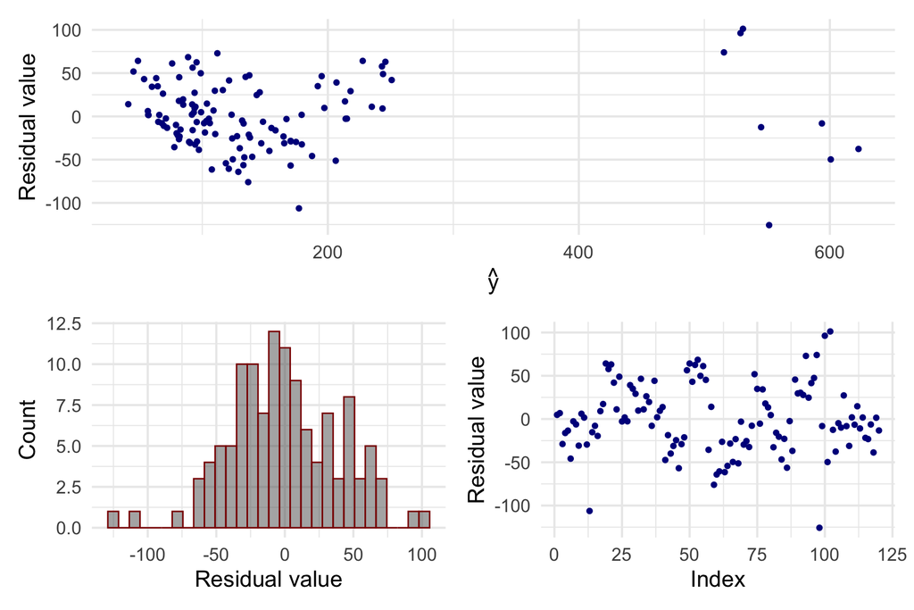

```r
plot_diagnostics_region(lm_pvi_south, FullStatesSouth)
```

**Midwest**

```r
FullStatesMidwest <- FullStates %>%
  filter(region == "Midwest")
```

Finding best-fit linear model PVI for states in the Midwest:

```r
lm_full_mw_pvi <- lm(npPVI ~ interior_perimeter_measure + county_splits + compactness_rank + maj_min + min_chance + factor(maptype), data = FullStatesMidwest)

lm_pvi_mw <- step(lm_full_mw_pvi, direction = "backward", results = "hide")
```

```
Start:  AIC=526.76
npPVI ~ interior_perimeter_measure + county_splits + compactness_rank +
    maj_min + min_chance + factor(maptype)

                             Df Sum of Sq   RSS    AIC
- compactness_rank            1     145.5 41984 525.04
- factor(maptype)             7    6982.4 48821 525.11
<none>                                    41839 526.76
- maj_min                     1    1331.1 43170 527.27
- county_splits               1    3274.8 45113 530.79
- interior_perimeter_measure  1    4294.3 46133 532.58
- min_chance                  1    6794.4 48633 536.80

Step:  AIC=525.04
npPVI ~ interior_perimeter_measure + county_splits + maj_min +
    min_chance + factor(maptype)

                             Df Sum of Sq   RSS    AIC
<none>                                    41984 525.04
- maj_min                     1    1245.3 43229 525.38
- factor(maptype)             7    9803.7 51788 527.83
- county_splits               1    3445.4 45430 529.35
- interior_perimeter_measure  1    4251.1 46235 530.76
- min_chance                  1    7855.6 49840 536.76
```

```r
tidy(lm_pvi_mw)
```

| term | estimate | std.error | statistic | p.value |
| --- | --- | --- | --- | --- |
| (Intercept) | -8.444825 | 14.4653275 | -0.5837977 | 0.561288019 |
| interior_perimeter_measure | 1.951287 | 0.7436328 | 2.6239925 | 0.010721116 |
| county_splits | 1.160533 | 0.4912751 | 2.3622883 | 0.021031239 |
| maj_min | 158.177261 | 111.3787669 | 1.4201743 | 0.160125752 |
| min_chance | 410.232813 | 115.0085061 | 3.5669780 | 0.000666958 |
| factor(maptype)Compact | 52.332266 | 18.8443131 | 2.7770854 | 0.007080963 |
| factor(maptype)Competitive | 20.681897 | 18.1618456 | 1.1387552 | 0.258801196 |
| factor(maptype)current | 28.701807 | 19.9687543 | 1.4373359 | 0.155208355 |
| factor(maptype)Dem | 21.901401 | 16.1804728 | 1.3535699 | 0.180355891 |
| factor(maptype)GOP | 27.895557 | 18.2695851 | 1.5268851 | 0.131427847 |

[output cut: 2 more lines]

The $r^2$ value:

```r
glance(lm_pvi_mw) %>%
  pull(adj.r.squared)
```

```
[1] 0.8692618
```

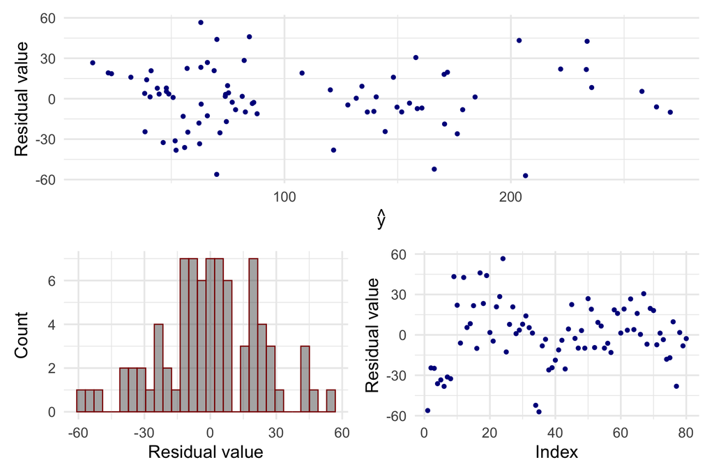

```r
plot_diagnostics_region(lm_pvi_mw, FullStatesMidwest)
```

**West**

```r
FullStatesWest <- FullStates %>%
  filter(region == "West")
```

Finding best-fit linear model PVI for states in the West:

```r
lm_full_west_pvi <- lm(npPVI ~ interior_perimeter_measure + county_splits + compactness_rank + maj_min + min_chance + factor(maptype), data = FullStatesWest)

lm_pvi_west <- step(lm_full_west_pvi, direction = "backward" , results = "hide")
```

```
Start:  AIC=660.23
npPVI ~ interior_perimeter_measure + county_splits + compactness_rank +
    maj_min + min_chance + factor(maptype)

                             Df Sum of Sq    RSS    AIC
- factor(maptype)             7      9304 231196 649.52
- min_chance                  1        94 221986 658.27
<none>                                    221892 660.23
- maj_min                     1      9853 231745 661.71
- county_splits               1     14639 236532 663.34
- compactness_rank            1     22923 244816 666.10
- interior_perimeter_measure  1    228658 450550 714.90

Step:  AIC=649.52
npPVI ~ interior_perimeter_measure + county_splits + compactness_rank +
    maj_min + min_chance

                             Df Sum of Sq    RSS    AIC
- min_chance                  1       596 231793 647.73
<none>                                    231196 649.52
- county_splits               1      8839 240035 650.52
- maj_min                     1     14589 245785 652.41
- compactness_rank            1     48867 280064 662.86
- interior_perimeter_measure  1    421491 652687 730.55

Step:  AIC=647.73
npPVI ~ interior_perimeter_measure + county_splits + compactness_rank +
    maj_min

                             Df Sum of Sq    RSS    AIC
<none>                                    231793 647.73
- county_splits               1      9759 241552 649.02
- compactness_rank            1     48315 280107 660.87
- maj_min                     1     49908 281700 661.33
- interior_perimeter_measure  1    422148 653940 728.70
```

```r
tidy(lm_pvi_west)
```

| term | estimate | std.error | statistic | p.value |
| --- | --- | --- | --- | --- |
| (Intercept) | -55.329170 | 15.3134275 | -3.613115 | 5.446356e-04 |
| interior_perimeter_measure | 8.658254 | 0.7408278 | 11.687269 | 1.457166e-18 |
| county_splits | 1.314523 | 0.7397426 | 1.777000 | 7.962282e-02 |
| compactness_rank | -11.685400 | 2.9554449 | -3.953855 | 1.727100e-04 |
| maj_min | 67.229267 | 16.7298818 | 4.018514 | 1.379805e-04 |

The $r^2$ value:

```r
glance(lm_pvi_west) %>%
  pull(adj.r.squared)
```

```
[1] 0.9451757
```

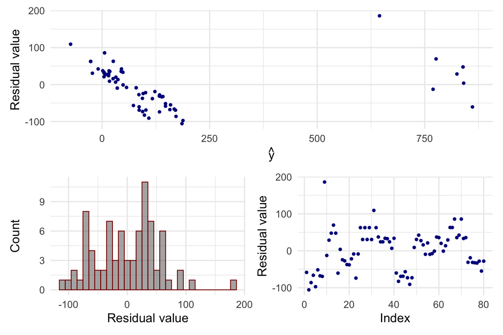

```r
plot_diagnostics_region(lm_pvi_west, FullStatesWest)
```

From the above analysis, it does not seem that any of the linear models created would fit assumptions needed for true hypothesis testing. Thus, the true predictive natures of the models is called into question, but it still might be useful to see which variables/predictors are associated with increasing PVI.

Here are the final linear models created for each of the above cases:

### For Northern States:

$$\widehat{npPVI} = 24 + 4.87~\mbox{(interior perimeter measure)} -
6.46~\mbox{(compactness ranking)} + 987~\mbox{(minority win chance)}$$

### For Southern States:

$$\widehat{npPVI} = 29.8 + 4.72~\mbox{(interior perimeter measure)} -
8.31~\mbox{(compactness ranking)} + 292~\mbox{(majorityminority districts)}$$
$$- 166~\mbox{(minority win chance)} + ~\mbox{(} 15.2~\mbox{if compact} -
18.7~\mbox{if competitive} + 14.8~\mbox{if current} + 4.78~\mbox{if Dem}$$
$$+ 24.7~\mbox{if GOP}
- 10.7~\mbox{if MajMin} + 21.7~\mbox{if Proportional)}$$

### For Western States:

$$\widehat{npPVI} = -55.3 + 8.66~\mbox{(interior perimeter measure)} +
1.31~\mbox{(county splits)}$$
$$- 11.7\mbox{(compactness ranking)} + 67.2~\mbox{(majorityminority districts)}$$

We examine some of the trends hinted at in the linear model in the following visualizations:

```r
lm_pvi_imp_north <- lm(npPVI ~ interior_perimeter_measure,  data = FullStatesMidwest)
```

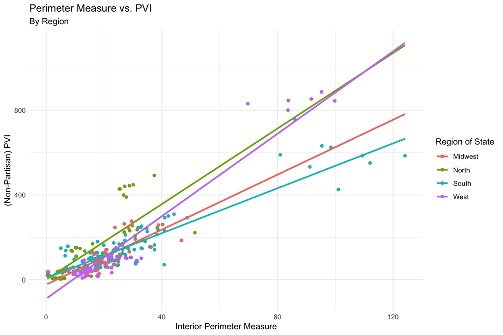

```r
FullStates %>%
  ggplot(mapping = aes(x = interior_perimeter_measure, y = npPVI, color = region))+
  geom_point()+
  geom_smooth(method = "lm", se = FALSE, fullrange = TRUE)+
  labs(x = "Interior Perimeter Measure", y = "(Non-Partisan) PVI",
       title = "Perimeter Measure vs. PVI",
       subtitle = "By Region",
       color = "Region of State")+
  theme_minimal()
```

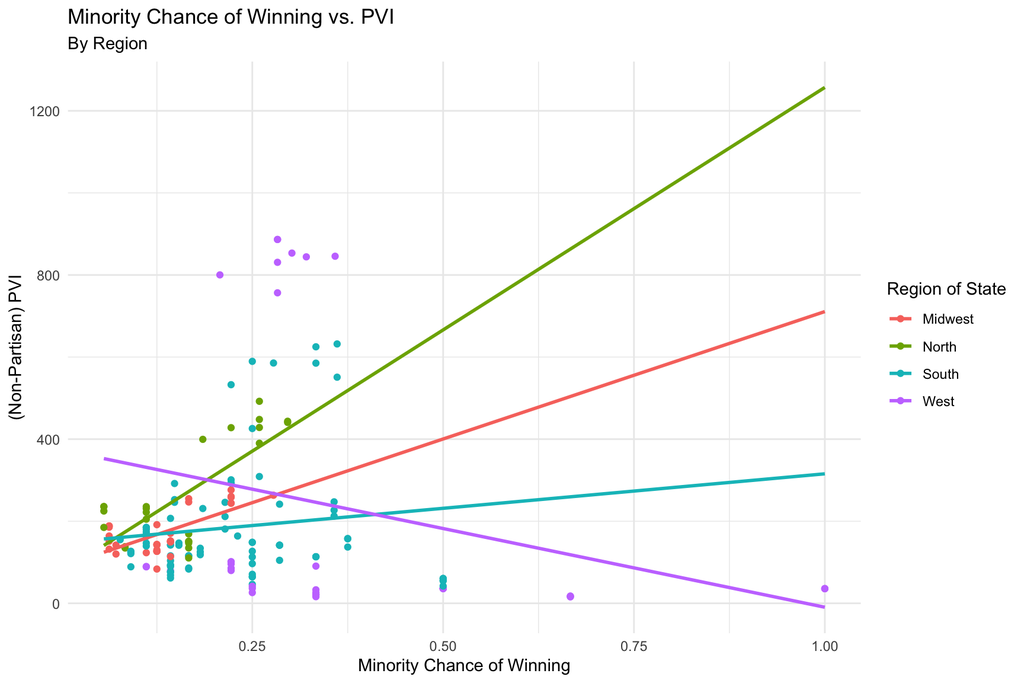

```r
FullStatesNoZeroMinChange <- FullStates %>%
  filter(min_chance != 0)

FullStatesNoZeroMinChange %>%
  ggplot(mapping = aes(x = min_chance, y = npPVI, color = region))+
  geom_point()+
  geom_smooth(method = "lm", se = FALSE, fullrange = TRUE)+
  labs(x = "Minority Chance of Winning", y = "(Non-Partisan) PVI",
       title = "Minority Chance of Winning vs. PVI",
       subtitle = "By Region",
       color = "Region of State")+
  theme_minimal()
```

## Discussion and Conclusion

Overall, the answer to our original research questions are inconclusive.

Modeling the political leanings of a district is tricky business. As we demonstrated in the previous section, while our linear models have very high $r^2$ values, which would indicate high predictive power, the assumptions for a linear model do not hold. We attempted to remedy the issue by subdividing the data into different geographic districts, but its clear that the overall relationship between the political leanings of a district and the various explanatory variables that we tested is not exactly linear. This isn’t entirely surprising; we are trying to model an incredibly complex phenomenon, public opinion. Additionally, because of the abnormal population: maps drawn by hand, using traditional statistical procedures that involve the central limit theorem seems strange. However, the nature of our analysis was not entirely to predict the fairness of different map types, but also to purely examine, in a statistically rigourous way, the relationship between certain measures associated with specific map and their effect on certain measures on maps.

Further analysis is needed to soundly conclude anything. The lack of consistent variance in our residuals reveals that the relationship between PVI and our selected map-drawing criteria is not linear, and therefore we cannot claim to model the effects with any level of conclusivity. Using different types of regressions/models may have been more fruitful. For example, instead of using PVI, we might have created created factor variables for Democratic, GOP, and Swing districts based on PVI cutoffs, and then fit a logistic regression to instead try and create a model that can accurately categorize districts based on map-drawing criteria. If anything, our analysis demonstrates aptly that political modeling is hugely complicated, and map-drawers must consider huge amounts of data and criteria in order to draw congressional districts, fair or otherwise.

Had the project been given the chance to restart, its clear that we would not attempt a linear model again. Assuming that partisan lean has a neat relationship with other non-political factors was misguided, and further analysis should explore more complicated relationships, like quadratic and logistic regressions. Further more, some of the variance in our residuals seem to indicate that our linear models are particularly bad at predicting the extreme PVI values. In order to discern if this is due to a non-linear relationship between PVI and our predictor variables versus these districts being somehow different from the others, we would need to identify these districts and test to see if they are significantly different from the other districts in our data. Perhaps these districts really are outliers in terms of demographics or some other non-political characteristic. Perhaps our model simply doesn’t capture the extremes of PVI well. Either way, more analysis would be needed to determine that. There are also other ways to subdivide the districts instead of simply by geographic region. For example, we could categorize districts into urban, rural, and suburban types, and perform analysis based on these different groups. They might reveal that different criteria are more predictive of PVI than others depending on the type of district that it falls in.

For the purposes of this project, we decided to go ahead and analyze our linear model as if the assumptions for a linear relationship held. We used a CLT-based hypothesis test to determine if there really are relationships between our explanatory variables and PVI. The result was a resounding yes for all variables at the 0.05 significance level.

Some variables, like map type, were somewhat of a given, especially the ones that were drawn to favor the Democrats or GOP, since PVI is a measure of Partisan Lean. Others, like compactness, hint at an urban-rural divide in modern politics that has been well-documented in recent elections. The intuitive understanding is that the smaller, compacter districts in urban areas favor Democrats, while more diffuse, rural districts favor Republicans. However, more testing would be needed to determine conclusively if compactness is truly a stand-in for urban/rural districts, or if its a unique measure.

Importantly, our original research aim was to find variables associated with electoral fairness. We looked at PVI and the Efficiency Gap as theoretical measures of this abstract concept. We ultimately disregarded our model for Efficiency Gap, because the explanatory variables were much worse at predicting the Efficiency Gap than PVI. Future models might try to develop another set of variables that more accurately predict Efficiency Gap, because this is a very complex and accurately measure of how counties are gerrymandered and where elections results differ from their intended behavior. Contrastingly, PVI does not incorporate the effeciency/intended behavior of districts. There is always the case that a map accurately reflects the opinions of a state’s constituents, even if the map is highly partisan, and as such it might not be the best measure of fairness. In the future, it would be interesting to use data collected of county-wide election results from the last state-wide senate races and could have tested the ability of different maps to accurately reflect state-wide races. This would highlight any discrepancies in the voting behavior of district-wide vs. state-wide results.

Overall, our linear model demonstrates how hard it is to truly model partisanship in congressional districts. Our assumptions for linear modeling did not hold no matter how we partitioned the data, which indicates a much more complicated relationship at play here. This means our data, through our failure to completely model the relationships we wanted to, hints at a broader truth: there is no one-size-fits-all solution to gerrymandering.

Some in the political arena want a single, all encompassing solution to the problems posed by drawing fair maps. Our analysis shows this is likely very difficult to find, because the factors at play do not relate to partisanship neatly. Through our difficulty in modeling political conditions throughout the United States, we reveal that, in the future, there cannot be a single criteria for drawing maps in order to promote fair elections. Rather, map-makers will need a wide array of data available, as the relationships between district-characteristics and election results is anything but simple and linear.

## Works Cited

Bycoffe, Aaron et al., “The Atlas of Redistricting.” January 25, 2018, FiveThirtyEight. https://projects.fivethirtyeight.com/redistricting-maps/wisconsin/#Competitive.

Jones, Jeffrey. “Democratic States Exceed Republican States by Four in 2018.” February 22, 2019. Gallup. https://news.gallup.com/poll/247025/democratic-states-exceed-republican-states-four-2018.aspx

U.S. Census Bureau, Census Regions and Divisions of the United States. n. date; https://www2.census.gov/geo/pdfs/maps-data/maps/reference/us_regdiv.pdf

[^1]: https://projects.fivethirtyeight.com/redistricting-maps/wisconsin/#Competitive
[^2]: https://www2.census.gov/geo/pdfs/maps-data/maps/reference/us_regdiv.pdf
[^3]: https://news.gallup.com/poll/247025/democratic-states-exceed-republican-states-four-2018.aspx